# Unit 4. Selection on the unobservables

UAB, 16-18 June, 2021

## When back-door conditioning is ineffective

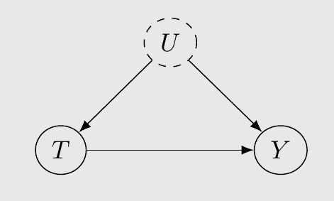

- Instrumental Variables methods are typically used to address endogeneity problems: failure of Unconfoundedness

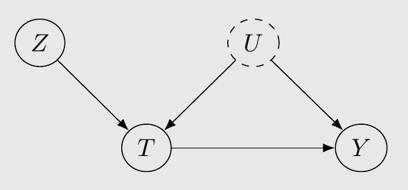

## IV Assumptions

1. Relevance

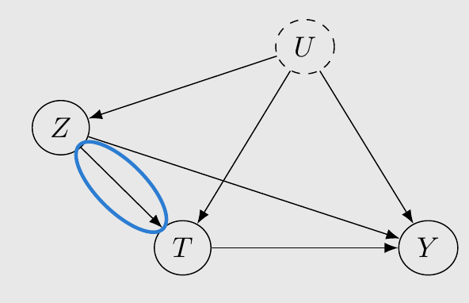

2. Exclusion Restriction

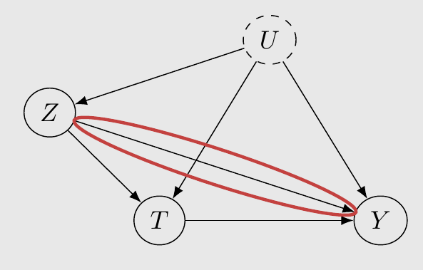

1. Instrumental Unconfoundedness (no unblockable backdoor path to Y)

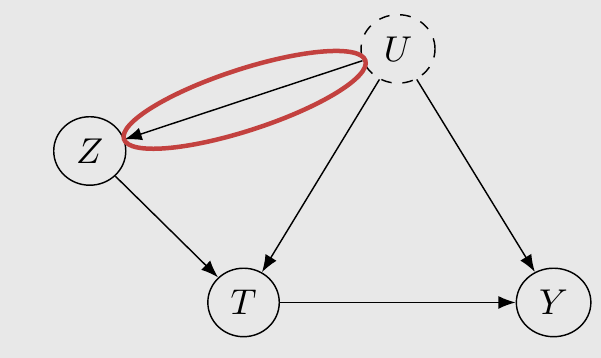

In general Conditional Instruments

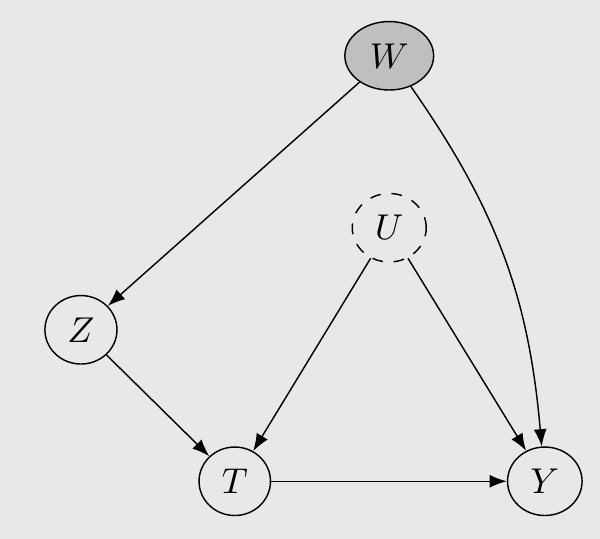

## IV Jargon

- Causal relationship of interest: \[\small Y_i = \delta_0 + \delta T_i + v_i\]
- First-Stage regression: \[\small T_i = \alpha_0 + \alpha_z Z_i + \varepsilon_i\]
- Second-Stage regression: \[\small Y_i = \delta_0 + \delta_z \widehat{T}_i + \nu_i\]
- Reduced form: \[\small Y_i = \pi_0 + \pi_1 Z_i + \epsilon_i\]

## Wald estimator

- The instrument is a binary indicator (for simplicity):

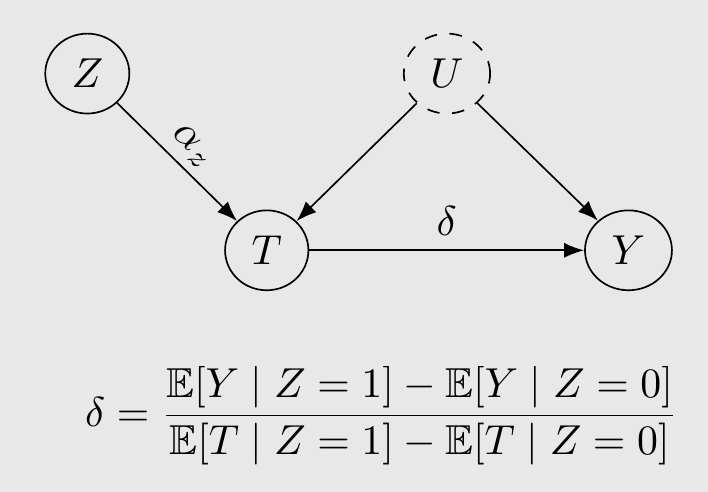

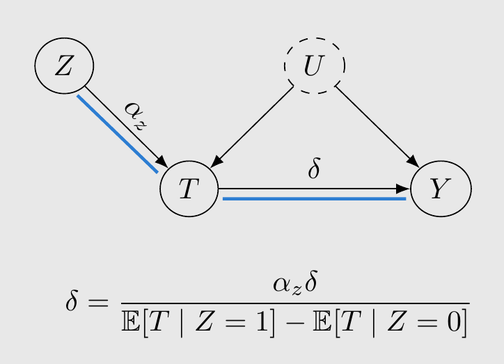

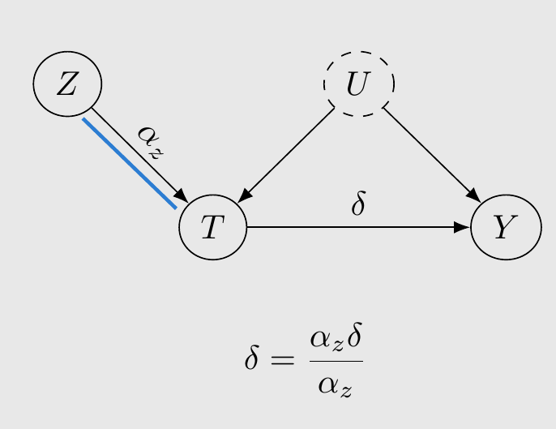

- In the continuous linear setting: \(\small \delta=\frac{Cov(Y,Z)}{Cov(T,Z)}\)

## Vietnam Draft Lottery as an IV

- Concerns about the fairness of the conscription policy lead to the introduction of a draft *lottery* in 1970.
  - From 1970 to 1972 random sequence numbers were assigned to each birth date in cohorts of 19-year-olds.
  - Men with lottery numbers below a cutoff were drafted while men with numbers above the cutoff could not be drafted.
- The draft did not perfectly determinate military service:
  - Many eligible men were exempted for health, schooling and other reasons
  - Non-eligible men volunteered for service

Note that using lotteries does NOT guarantee that we have a Randomized Control Trial (more on this later)

## Generalized Potential Outcomes Framework

- \(Y(1)\) and \(Y(0)\) are short for \(Y(T=1)\) and \(Y(T=0)\): \(T \rightarrow Y\)
- We also have \(Y(Z=1)\) and \(Y(Z=0)\): \(Z \rightarrow Y\)
- Now we have \(T(Z=1)\) and \(T(Z=0)\), or \(T(1)\) and \(T(0)\) for short:\(Z \rightarrow T\)

## Four groups in data

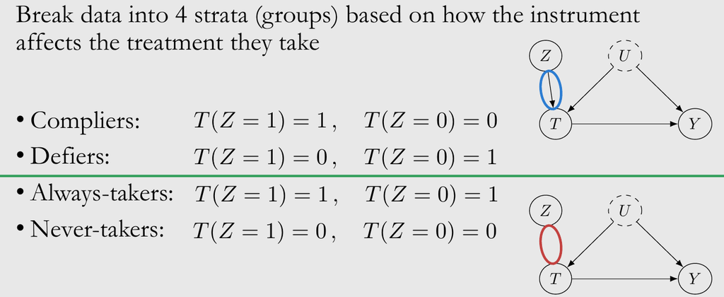

## The LATE Theorem

- In general causal effects are heterogenous
- Under the three standar IV Assumptions plus **Monotonicity** (No Defiers) \[ \small T(Z_i=1) \geq T(Z_i=0), \forall i \]
- The IV estimand identifies the **LATE** (Local Average Treatment Effect)
- The **LATE** identified by IV methods is the average causal effect of \(D\) on \(Y\) on the sub-group affected by the instrument: those who were treated due to \(Z\) but would not be treated otherwise
  - This is a generally unidentifiable subpopulation.

## Weak Instruments

- IV can be severely biased in particular if instruments are weak and if you use many instruments
  - In the worst case, the 2SLS sampling distribution is centered on the probability limit of OLS.
- It is important to report the first stage and test the (joint) relevance of instruments

## Dif-in-Dif Example

- In February 1992 NJ increased the state minimum wage from \(4.25\) to \(5.05\) US$, while in Pennsylvania minimum wage stayed at \(4.25\)
- Is the change from Feb. to Nov. in NJ a causal effect? \[ \small E [Y_{ist} | s = NJ, t = N ] - E [Y_{ist} | s = NJ, t = F ] \]
  - NO: other factors affecting employment may have changed
- Is the difference between NJ and PA in November a causal effect? \[ \small E [Y_{ist} | s = NJ, t = N ] - E [Y_{ist} | s = PA, t = N ] \]
  - NO: systematic differences in employment may exist between them
  - NJ may be “self-selected” into the treatment of changing minimum wage

## Differences-in-Differences

- The differences-in-differences strategy amounts to comparing the change in employment in NJ to the change in employment in PA. \[ \small \begin{align*} &\left( E [Y_{ist} | s = NJ, t = N ] - E [Y_{ist} | s = NJ, t = F ] \right) \\ -&\left( E [Y_{ist} | s = PA, t = N ] - E [Y_{ist} | s = PA, t = F ] \right) \end{align*} \]
- Or equivalently (re-arranging terms), comparing the difference in employment between NJ and PA after with the same difference before

\[ \small \begin{align*} &\left( E [Y_{ist} | s = NJ, t = N ] - E [Y_{ist} | s = PA, t = N ] \right) \\ -&\left( E [Y_{ist} | s = NJ, t = F ] - E [Y_{ist} | s = PA, t = F ] \right) \end{align*} \]

## Regression Diff-in-Diff

- Advantages:
  - It is easy to calculate standard errors.
  - We can control for other variables which may reduce the residual variance (lead to smaller standard errors).
  - It is easy to include multiple periods.
  - We can study treatments with different treatment intensity. (e.g. varying increases in the minimum wage for different states).
- The typical regression model that we estimate is: \[ \small Outcome_{it} = \beta_1 + \beta_2 Treat_i + \beta_3 Post_t + \color{red}{\beta_4} (Treat * Post)_{it} + \varepsilon_{it} \]
  - \(Treat\) = a dummy if the observation is in the treatment group
  - \(Post\) = post-treatment dummy (“after”)

## Diff-in-Diff Graph

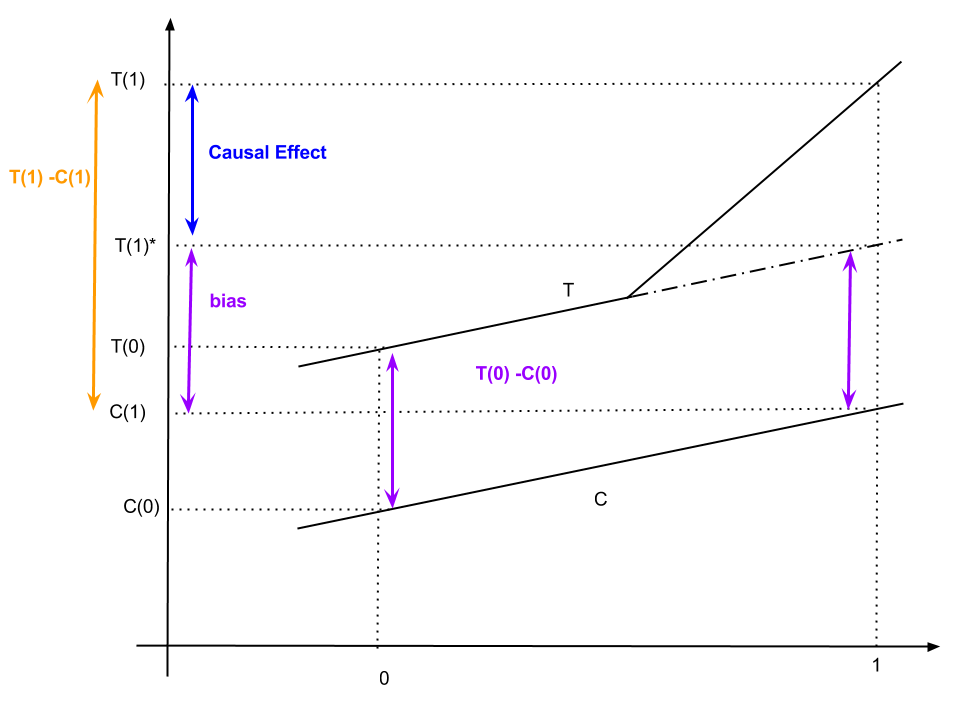

## Diff-in-Diff Graph (cont’d)

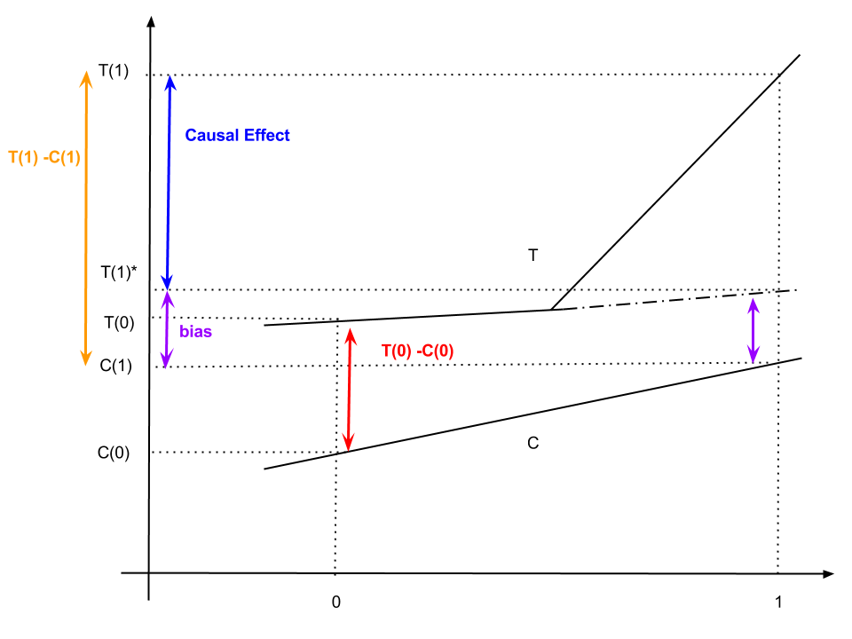

## Key Assumption: Common Trends

- The key assumption for any Diff-in-Diff strategy is that the outcome in treatment and control group would follow the same time trend in the absence of the treatment.
- They just follow **parallel paths**
- Common trend assumption is difficult to verify but one often uses pre-treatment data to show that the trends are the same.
  - Using leads and lags in regression models
- Even if pre-trends are the same one still has to worry about other policies changing at the same time.

## Key Assumption: Common Trends (cont’d)

- This method is intended to give a *proper counterfactual*
1. \((NJ Post - \color{red}{NJ Pre) - (PA Post - PA Pre) }\)
   - the second difference “purge” the common trend
2. \((NJ Post - \color{red}{PA Post) - (NJ Pre - PA Pre) }\)
   - the second difference “purge” the original systematic differences (that remains given the common evolution in the absence of treatment)
- This assumption is often more credible, *conditional* on additional regressors

\[ \small Y_{ist} = \alpha+ \gamma T_s + \lambda d_t + \delta (T_s d_t) + \beta X_{ist} + \varepsilon_{ist} \]

- When controlling for other characteristics, we assume common trends *ceteris paribus*

## Standard Errors in Diff-in-Diff Strategies

- As pointed out before, many papers using a Diff-in-Diff strategy use data from many years (not only one pre and one post period).
- The variables of interest in many of these setups only vary at a group level (say, state)
- Bertrand, Duflo, and Mullainathan (2004) propose the following solutions:
  1. Clustering standard errors at the group level.
  2. Aggregating the data into one pre and one post period.
- Correct treatment of standard errors sometimes makes the number of groups very small

## Synthetic Control Methods

- Abadie & Gardeazabal (2003) pioneered a synthetic control method when estimating the effects of the terrorist conflict in the Basque Country using other Spanish regions as a comparison group.
- Card (1990) implicitly used a very similar approach in his Mariel boatlift paper investigating the effect of immigration on employment of natives.
- The basic idea behind synthetic controls is that a combination of units often provides a better comparison for the unit exposed to the intervention than any single unit alone.
  - It is important to “show” that the combined control group is ex-ante similar to the treatment group.

## The Basque Country is Different

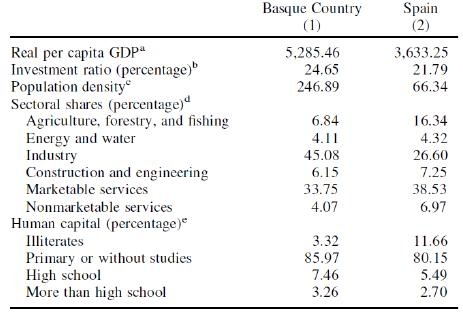

## The Synthetic Control Method

- They have \(J\) available control regions (the 16 Spanish regions other than the Basque Country).
- They want to assign weights \(W = (w_1, ..., w_J )'\) to each region with \(w_j \ge0\) and \(\sum w_j = 1\)
- This ensures that there is no extrapolation outside the support of the growth predictors for the control regions.
- The weights are chosen so that the synthetic Basque country most closely resembles the actual one before terrorism by minimizing: \[ \small (X_1- X_0 W)'V(X_1- X_0 W) \]
- Implemented in Stata, R and python: library `synth`

## The Synthetic Basque Country Looks Similar

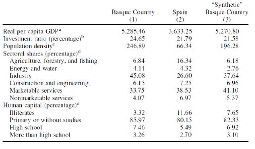

## Growth in the Basque Country with and without Terrorism

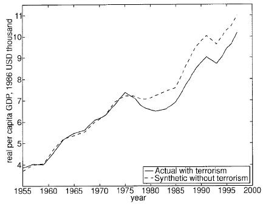